# IODS course project

Vilna Tyystjärvi

# Introduction to Open Data Science - Course Project

# About the project

*Write a short description about the course and add a link to your GitHub repository here. This is an R Markdown (.Rmd) file so you should use R Markdown syntax.*

```r
# This is a so-called "R chunk" where you can write R code.

date()
```

```
## [1] "Fri Nov 13 00:10:11 2020"
```

Still a bit confused, I got back from fieldwork in Central Finland on Thursday and took the rest of the week off. But excited to start the course! Link to repo: https://github.com/vilnat/IODS-project

# Week 2 - Regression and model validation

*Describe the work you have done this week and summarize your learning.*

- Describe your work and results clearly.
- Assume the reader has an introductory course level understanding of writing and reading R code as well as statistical methods.
- Assume the reader has no previous knowledge of your data or the more advanced methods you are using.

```r
date()
```

```
## [1] "Fri Nov 13 00:10:12 2020"
```

## Dataset

```r
d14 <- read.table("data/learning2014.csv")
str(d14)
```

```
## 'data.frame':    166 obs. of  7 variables:
##  $ gender  : Factor w/ 2 levels "F","M": 1 2 1 2 2 1 2 1 2 1 ...
##  $ age     : int  53 55 49 53 49 38 50 37 37 42 ...
##  $ attitude: num  3.7 3.1 2.5 3.5 3.7 3.8 3.5 2.9 3.8 2.1 ...
##  $ deep    : num  3.58 2.92 3.5 3.5 3.67 ...
##  $ stra    : num  3.38 2.75 3.62 3.12 3.62 ...
##  $ surf    : num  2.58 3.17 2.25 2.25 2.83 ...
##  $ points  : int  25 12 24 10 22 21 21 31 24 26 ...
```

```r
dim(d14)
```

```
## [1] 166   7
```

This dataset contains information about a survey study conducted in a intro course to social statistics in the University of Helsinki. The study focused on the relationship between learning approaches and students' achievements. The dataset contains background information of each student, such as the gender, age and how well they did in the course exam. It also contains aggregated information about the survey results in columns "deep", "stra" and "surf" which correspond to deep, strategic and surface learning.

This plot shows a summary of the variables in the dataset. The line graphs in the middle of the plot show the distribution in the data. Most of the data apart from background information is fairly normally distributed. Aggregated deep learning variable is a bit skewed towards high values. The scatter plots and numerical values surrounding the line graphs show correlations inside the data. Most strongly correlated are attitude towards statistics and how well the student did in the exam (positive correlation) as well as deep and surface learning (negative correlation).

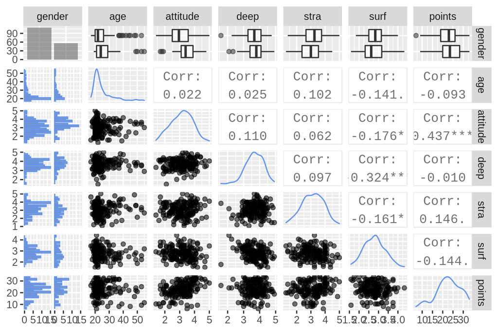

```r
library(ggplot2)
library(GGally)

p <- ggpairs(d14, mapping = aes(alpha = 0.5), lower = list(combo = wrap("facethist", bins = 20, colour = "cornflower blue")), diag = list(continuous = wrap("densityDiag", colour = "cornflower blue")))
p
```

Finally, here is a summary of the variables:

```r
summary(d14)
```

```
##  gender       age           attitude          deep            stra
##  F:110   Min.   :17.00   Min.   :1.400   Min.   :1.583   Min.   :1.250
##  M: 56   1st Qu.:21.00   1st Qu.:2.600   1st Qu.:3.333   1st Qu.:2.625
##          Median :22.00   Median :3.200   Median :3.667   Median :3.188
##          Mean   :25.51   Mean   :3.143   Mean   :3.680   Mean   :3.121
##          3rd Qu.:27.00   3rd Qu.:3.700   3rd Qu.:4.083   3rd Qu.:3.625
##          Max.   :55.00   Max.   :5.000   Max.   :4.917   Max.   :5.000
##       surf           points
##  Min.   :1.583   Min.   : 7.00
##  1st Qu.:2.417   1st Qu.:19.00
##  Median :2.833   Median :23.00
##  Mean   :2.787   Mean   :22.72
##  3rd Qu.:3.167   3rd Qu.:27.75
##  Max.   :4.333   Max.   :33.00
```

## Linear model

Here I built a linear model that explains exam success based on the variables *attitude*, *strategic learning* and *age*. I chose these variables based on backward elimination method in which you add all explanatory variables in the model and delete one by one the least significant variables until you're left with variables that are statistically significant.

The summary below shows the statistical aspects of the model. The residuals are relatively well normally distributed. Of the explanatory variables, attitude is clearly the most significant statistically. It has a strong positive influence on test results. While you could spend a while discussing whether ~0.05 is 'good enough', I chose to keep strategic learning and age in the model as they improve the r<sup>2</sup> value. Higher strategic learning value in the model leads to higher test results whereas age has a slightly negative influence on them. Overall the model explains approximately 22 % of the exam results (multiple r<sup>2</sup> = 0.2182) so a large part of the variation is still left unexplained.

```r
m <- lm(points ~ attitude + stra + age, data = d14)
summary(m)
```

```
##
## Call:
## lm(formula = points ~ attitude + stra + age, data = d14)
##
## Residuals:
##      Min       1Q   Median       3Q      Max
## -18.1149  -3.2003   0.3303   3.4129  10.7599
##
## Coefficients:
##             Estimate Std. Error t value Pr(>|t|)
## (Intercept) 10.89543    2.64834   4.114 6.17e-05 ***
## attitude     3.48077    0.56220   6.191 4.72e-09 ***
## stra         1.00371    0.53434   1.878   0.0621 .
## age         -0.08822    0.05302  -1.664   0.0981 .
## ---
## Signif. codes:  0 '***' 0.001 '**' 0.01 '*' 0.05 '.' 0.1 ' ' 1
##
## Residual standard error: 5.26 on 162 degrees of freedom
## Multiple R-squared:  0.2182, Adjusted R-squared:  0.2037
## F-statistic: 15.07 on 3 and 162 DF,  p-value: 1.07e-08
```

Linear models make certain assumptions concerning the nature of the data and the relationships between the model and the dependent variable. Model residuals show the difference between actual observations and the model. Linear models assume that these residuals are normally distributed and that their values don't depend on the dependent variable. The top-left figure below (residuals vs. fitted) shows the spread of the residuals across the fitted values. There doesn't seem to be any clear pattern although some of the residuals are somewhat separated from the general lump. Don't really know what is happening there but these residuals also aren't dependent on the fitted values.

The top-right figure shows how normally the residuals are distributed. For the most part, the residuals are close to the central line which means that they're mostly normally distributed aside from the highest negative residuals which are shown in the bottom left of that figure.

The final figure shows the influence of each individual observation on the model results. As seen, none of the observations have an unreasonably high influence on the model, meaning that there aren't any clear outliers that could be removed to improve it.

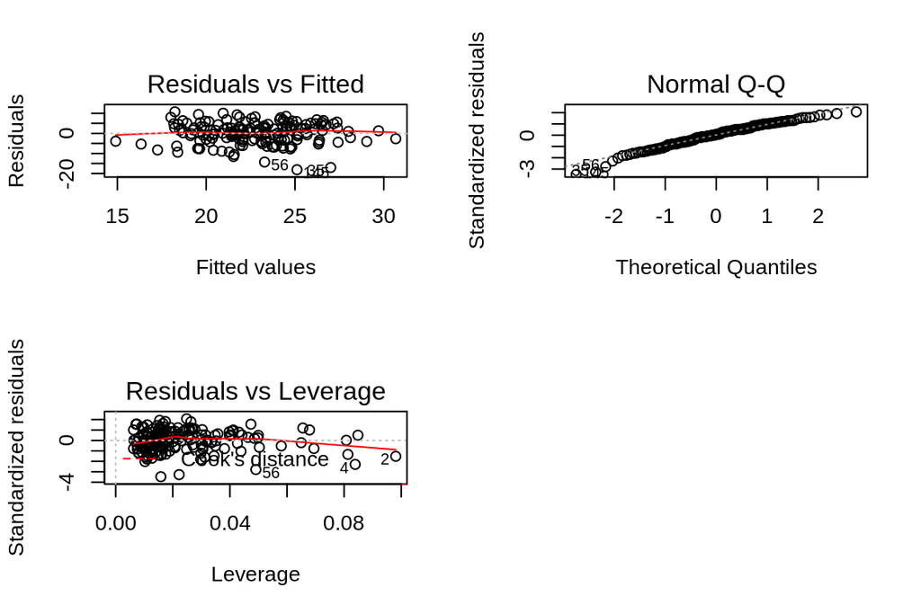

```r
par(mfrow = c(2,2))
plot(m, which = c(1,2,5))
```

# Week 3 - Logistic regression

```r
date()
```

```
## [1] "Fri Nov 13 00:10:20 2020"
```

This dataset contains information about students in two Portuguese schools. The data includes various attributes of the students such as their family background and social activities as well as grade data from two classes, math and Portuguese. The original data is available here: https://archive.ics.uci.edu/ml/datasets/Student+Performance

```r
data <- read.table("data/alcohol_is_bad.csv", sep = ";", header = TRUE)
colnames(data)
```

```
##  [1] "school"     "sex"        "age"        "address"    "famsize"
##  [6] "Pstatus"    "Medu"       "Fedu"       "Mjob"       "Fjob"
## [11] "reason"     "nursery"    "internet"   "guardian"   "traveltime"
## [16] "studytime"  "failures"   "schoolsup"  "famsup"     "paid"
## [21] "activities" "higher"     "romantic"   "famrel"     "freetime"
## [26] "goout"      "Dalc"       "Walc"       "health"     "absences"
## [31] "G1"         "G2"         "G3"         "alc_use"    "high_use"
```

The data also contains information about the students' alcohol consumption which gives us the opportunity to study what characteristics might correlate with it. For this, I chose four interesting variables that might or might not explain alcohol consumption.

- "higher" = binary variables, whether or not the student wants to pursuit higher education. This might correlate negatively with alcohol usage, i.e. if you want to get higher education, you probably drink less (at least for now)
- "activities" = binary variable, whether or not the student takes extra-curricular activities, again probably correlating negatively with alcohol usage, at least if we're thinking of overly stereotypical teenagers
- "famrel" = a variable ranging from 1 to 5, describing how good the student's relationship is with their family. Might correlate negatively with alcohol usage (i.e. bad family relationship leads to drinking)
- "goout" = again, a variable ranging from 1 to 5, describing how much the student goes out with friends, possibly correlating positively with alcohol, because what else would you do with friends?

Now, let's see how they actually compare to alcohol usage.

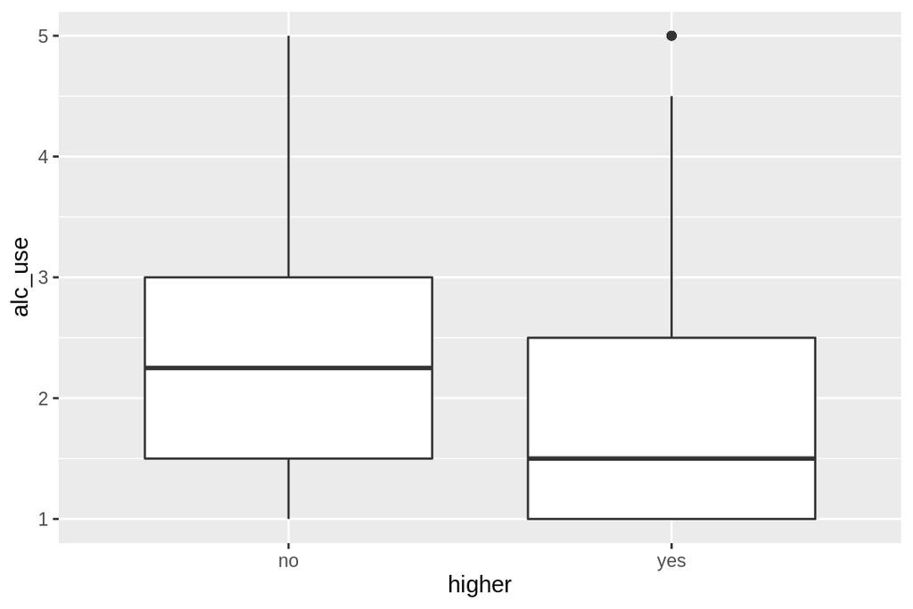

```r
library(ggplot2)
library(dplyr)
g1 <- ggplot(data = data, aes(x=higher, y = alc_use))
g1 + geom_boxplot()
```

```r
data %>% group_by(higher, high_use) %>% summarise(count = n())
```

```
## # A tibble: 4 x 3
## # Groups:   higher [2]
##   higher high_use count
##   <fct>  <lgl>    <int>
## 1 no     FALSE        9
## 2 no     TRUE         9
## 3 yes    FALSE      259
## 4 yes    TRUE       105
```

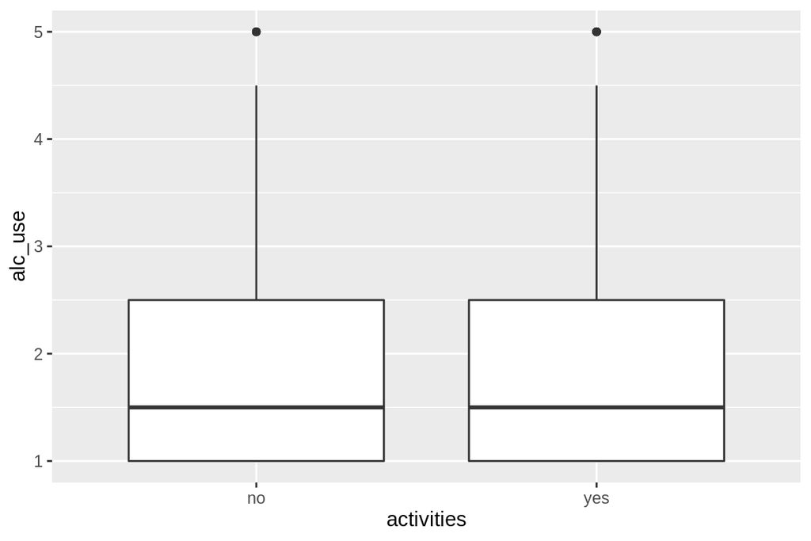

```r
g1 <- ggplot(data = data, aes(x=activities, y = alc_use))
g1 + geom_boxplot()
```

```r
data %>% group_by(activities, high_use) %>% summarise(count = n())
```

```
## # A tibble: 4 x 3
## # Groups:   activities [2]
##   activities high_use count
##   <fct>      <lgl>    <int>
## 1 no         FALSE      122
## 2 no         TRUE        59
## 3 yes        FALSE      146
## 4 yes        TRUE        55
```

Seems like there is no visible relationship between alcohol usage and extra-curricular activities. This is not that surprising and my original hypothesis was rather weak.

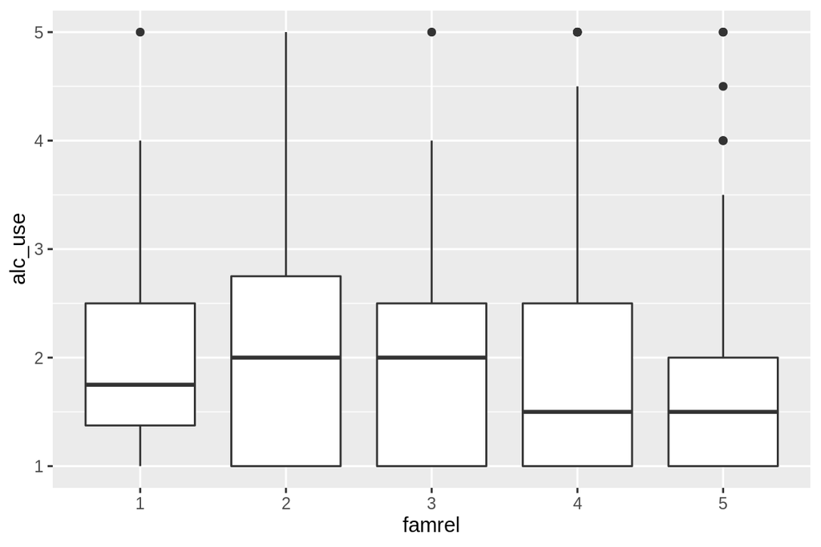

```r
data$famrel <- as.character(data$famrel) #No idea what is wrong with this, I'd imagine it should work with integers as well but I guess not
g1 <- ggplot(data = data, aes(x=famrel, y = alc_use))
g1 + geom_boxplot()
```

```r
data %>% group_by(famrel, high_use) %>% summarise(count = n())
```

```
## # A tibble: 10 x 3
## # Groups:   famrel [5]
##    famrel high_use count
##    <chr>  <lgl>    <int>
##  1 1      FALSE        6
##  2 1      TRUE         2
##  3 2      FALSE       10
##  4 2      TRUE         9
##  5 3      FALSE       39
##  6 3      TRUE        25
##  7 4      FALSE      135
##  8 4      TRUE        54
##  9 5      FALSE       78
## 10 5      TRUE        24
```

There seems to be a small relationship between particularly good family relationships and less alcohol usage. The less clear relationship in the lower end might be caused by a smaller number of students. This is inline with my original assumptions, yey me.

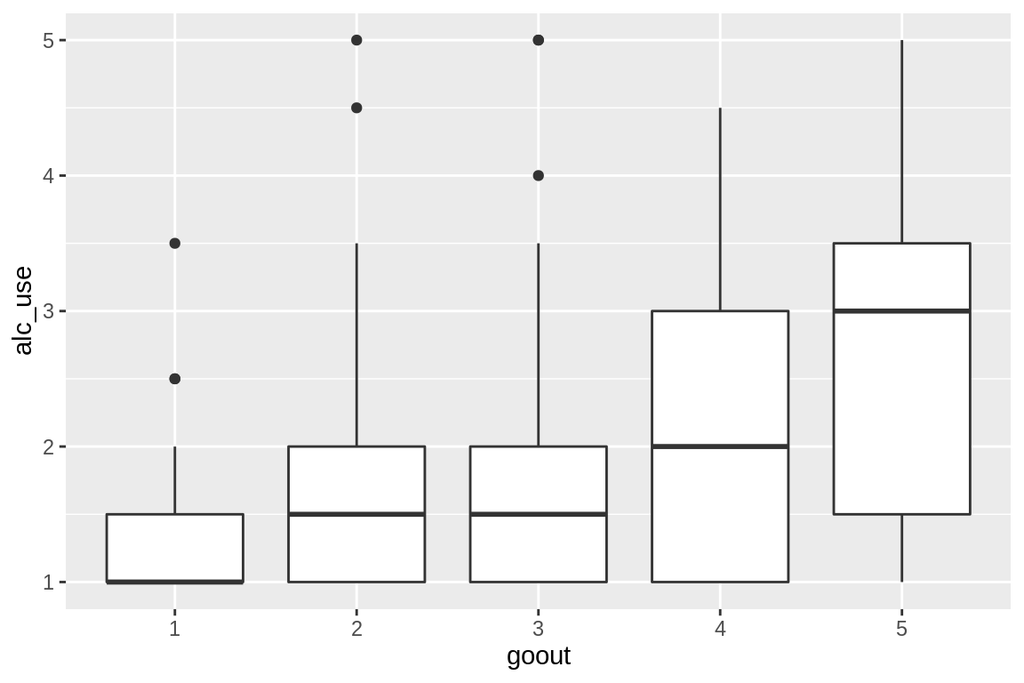

```r
data$goout <- as.character(data$goout) #No idea what is wrong with this, I'd imagine it should work with integers as well but I guess not
g1 <- ggplot(data = data, aes(x=goout, y = alc_use))
g1 + geom_boxplot()
```

At least there is a clear positive correlation with alcohol usage and going out with friends. I managed to guess something right.

And now it's midnight and I'm falling asleep. So thanks for grading this far, feel free to move on to the next person.